# Homework 01

## TidyTuesday Section

Explore the week’s [TidyTuesday](https://github.com/rfordatascience/tidytuesday) challenge. Develop a research question, then answer it through a short data story with effective visualization(s). Provide sufficient background for readers to grasp your narrative.

## Data Import

```r
library(ggplot2)
library(dplyr)

tuesdata <- tidytuesdayR::tt_load(2026, week = 4)

companies <- tuesdata$companies
legal_nature <- tuesdata$legal_nature
qualifications <- tuesdata$qualifications
size <- tuesdata$size
```

## Introduction

Brazil’s CNPJ registry provides detailed information on the legal structure, size, and declared share capital of registered firms, offering insight into how businesses are organized economically. Given this data set, I will explore the research question: How does declared share capital differ by company size and legal status?

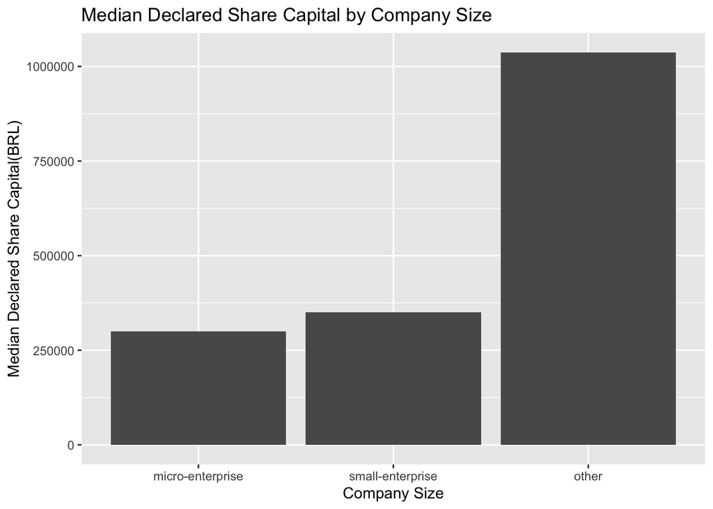

```r
companies |>
  group_by(company_size) |>
  summarize(median_capital = median(capital_stock)) |>
  mutate(company_size = factor(company_size,
                               levels = c("micro-enterprise",
                                          "small-enterprise",
                                          "other"))) |>
  ggplot(aes(x = company_size, y = median_capital)) +
  geom_col() +
  labs(title = "Median Declared Share Capital by Company Size",
       y = "Median Declared Share Capital(BRL)",
       x = "Company Size")
```

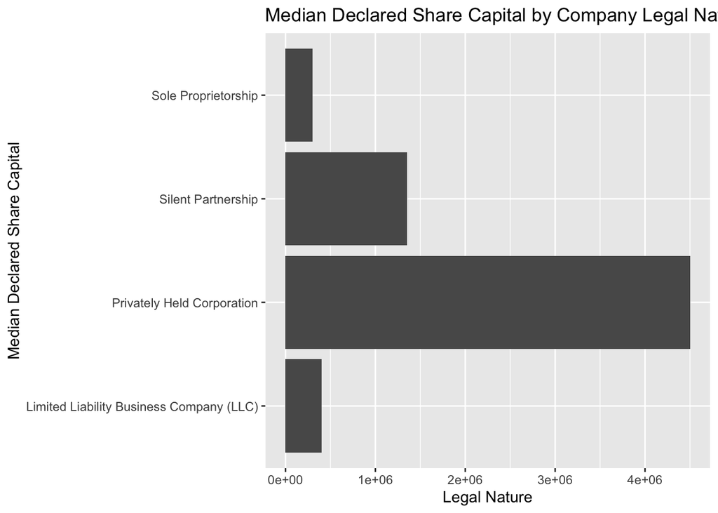

```r
top_legal_nature <- companies |>
  count(legal_nature, sort = TRUE) |>
  slice_head(n = 4)

companies_top_legal <- companies |>
  semi_join(top_legal_nature, by = "legal_nature")

companies_top_legal |>
  group_by(legal_nature) |>
  summarize(median_capital = median(capital_stock)) |>
  ggplot(aes(x = legal_nature, y = median_capital)) +
  geom_col() +
  coord_flip() +
  labs(title = "Median Declared Share Capital by Company Legal Nature",
       x = "Median Declared Share Capital",
       y = "Legal Nature")
```

## Discussion

Examining median declared share capital reveals clear differences across both company size and legal nature. Unsurprisingly, median capital increases with size. Firms classified as “other” tend to have substantially higher median capital than micro and small enterprises, suggesting greater financial resources and higher barriers to entry. At the same time, legal structure matters independently of size: privately held corporations exhibit far higher median capital than limited liability companies, sole proprietorships, or silent partnerships. Together, these patterns indicate that both firm size and institutional form are strongly associated with capital intensity in Brazilian businesses. But, does the tendency for median capital stock to increase with company size prevail when you look at it within each each legal nature on its own.

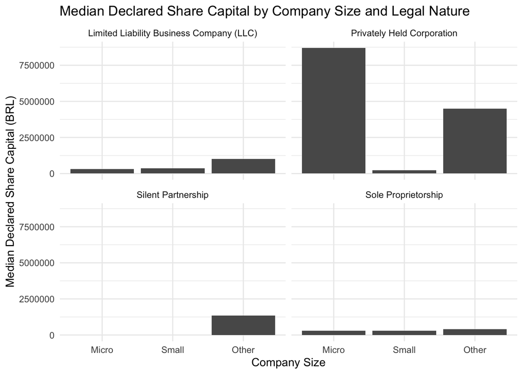

```r
companies_top_legal |>
  group_by(company_size, legal_nature) |>
  summarize(median_capital = median(capital_stock), .groups = "drop") |>
  mutate(company_size = factor(company_size,
                               levels = c("micro-enterprise",
                                          "small-enterprise",
                                          "other")),
         company_size = recode(company_size,
                             "micro-enterprise" = "Micro",
                             "small-enterprise" = "Small",
                             "other" = "Other")) |>
  ggplot(aes(x = company_size, y = median_capital)) +
  geom_col() +
  facet_wrap(~ legal_nature) +
  labs(
    title = "Median Declared Share Capital by Company Size and Legal Nature",
    x = "Company Size",
    y = "Median Declared Share Capital (BRL)"
  ) +
  theme_minimal()
```